# Medevac Interrater Reliability Analysis

Right Answer vs Wrong Answer Vignette Classes

Author

Medevac Interrater Study Team

Published

November 10, 2025

# Analysis Plan

## Overview

This document outlines the analytic framework for evaluating **interrater reliability and decision variability** among 20 physicians reviewing 20 standardized medevac vignettes. Each physician selected one of three management options:

1. **Medevac** – Immediate air evacuation
2. **Commercial** – Next available commercial flight
3. **Remain** – Stay in village for continued observation/treatment

Each physician also provided a confidence rating (1–10 scale). Because each physician rated multiple vignettes, data are structured as **repeated measures**, with responses nested within physicians.

## Vignette Classes

| Class | Description | N Vignettes | Example Focus |
| --- | --- | --- | --- |
| **A. Expert Consensus** | Clear affirmative cases with a “suggested best” expert answer | 8 | Clear Medevac or Clear Remain |
| **B. Expert Boundary** | Cases where one option is *discouraged* but two are acceptable | 6 | Clear Not Medevac / Clear Not Remain |
| **C. Ambiguous** | All options clinically reasonable | 3 | Any Option / Equivocal |
| **D. Situational** | Emergencies constrained by logistics (bimodal expected) | 3 | Conflict Between Physiology and Logistics |

## Vignette Mapping Table

| **Q#** | **Question Type** | **Class** |
| --- | --- | --- |
| 1 | Clear Medevac | A |
| 2 | Clear Not Medevac | B |
| 3 | Any Option | C |
| 4 | Clear Medevac | A |
| 5 | Clear Not Medevac | B |
| 6 | Clear Not Medevac | B |
| 7 | Clear Not Remain | B |
| 8 | Clear Remain | A |
| 9 | Clear Commercial | A |
| 10 | Clear Not Remain | B |
| 11 | Clear Remain | A |
| 12 | Any Option | C |
| 13 | Clear Medevac | A |
| 14 | Clear Not Medevac | B |
| 15 | Clear Commercial | A |
| 16 | Conflict Between Physiology/Logistics | D |
| 17 | Conflict Between Physiology/Logistics | D |
| 18 | Conflict Between Physiology/Logistics | D |
| 19 | Clear Medevac | A |
| 20 | Any Option | C |

## Use of Gwet’s AC1 for Interrater Reliability

Traditional kappa coefficients, such as Cohen’s κ or Fleiss’ κ, are highly sensitive to **prevalence bias**—situations where one response option dominates. Because many vignettes in this study were designed to elicit a clear “correct” or expert-preferred decision, the distribution of responses is intentionally unbalanced. Under these conditions, κ often yields artificially low or even negative values despite substantial agreement, a phenomenon known as the *kappa paradox*.

To overcome this limitation, we use **Gwet’s AC1** as the primary measure of interrater reliability for Classes A (Expert Consensus) and B (Expert Boundary). AC1 adjusts the expected probability of chance agreement to be independent of marginal category prevalence, resulting in a more stable and interpretable estimate of agreement when response distributions are skewed.

## Application of Generalized Linear Mixed Models (GLMM)

Although each physician evaluates each vignette only once, the dataset contains multiple responses per physician across different scenarios. These repeated observations are **not independent**, as each physician’s individual reasoning style, experience, and risk tolerance influence all of their decisions. Similarly, each vignette varies in intrinsic difficulty or clarity.

To properly account for these nested dependencies, all inferential analyses use **Generalized Linear Mixed Models (GLMMs)** with random intercepts for both *physician* and *vignette*. This approach partitions the variance into within- and between-clinician components, controlling for clustering and reducing inflated Type I error that would arise from treating responses as independent.

The random effects capture:

- **Physician-level heterogeneity** — differences in baseline propensity to choose medevac versus conservative management.
- **Vignette-level heterogeneity** — differences in clarity, context, or complexity of the clinical scenario.

GLMMs are therefore well suited to this repeated-measures design, providing unbiased estimates of fixed effects (e.g., class-level trends, alignment with expert guidance) while preserving the natural correlation structure of the data.

## Class-Specific Statistical Approach

### Class A – Expert Consensus (Suggested Best Answer)

**Goal:** Measure alignment with the expert-recommended option and consistency among physicians.

**Descriptive Stats:**

- Proportion choosing the expert answer
- Shannon entropy (decision diversity)
- Mean ± SD confidence

**Analytic Statistic:** **Gwet’s AC1** (for overall agreement)

**Visualization:** Binary heatmap (physicians × vignettes; green = expert aligned), bar plots of agreement proportion.

### Class B – Expert Boundary (One Discouraged Answer)

**Goal:** Quantify consistency in avoiding discouraged responses.

**Descriptive Stats:**

- % choosing discouraged option
- Entropy and confidence scores

**Analytic Statistic:** **Gwet’s AC1** (binary acceptable vs discouraged)

**Visualization:** Stacked bar charts showing acceptable vs discouraged, and 3-color heatmap across vignettes.

### Class C – Ambiguous (All Plausible Options)

**Goal:** Describe distributional diversity under uncertainty.

**Descriptive Stats:**

- Proportion per option
- Entropy (higher = more diverse)

**Analytic Statistic:** χ² goodness-of-fit test vs equal (33.3%) distribution.

**Visualization:** 3-color heatmap or ternary plot of decision mix.

### Class D – Situational (Operationally Constrained Emergencies)

**Goal:** Describe variability (bimodal split Medevac vs Remain).

**Descriptive Stats:**

- Proportion choosing each option
- Entropy and confidence summary

**Analytic Statistic:** Exact binomial test vs 50/50 split.

**Visualization:** Diverging bar plot (% Medevac vs Remain) and 2-color heatmap of clinician patterns.

## Sample Size and Feasibility

- 400 total responses (20×20) provide adequate power for AC1 and GLMMs.
- Class-level AC1 and entropy estimates are stable; per-vignette κ was dropped.
- Small cell counts (<3 raters per category) are handled via exact tests.

## Standardized Analytic Framework

| Step | Metric | Applies To | Purpose |
| --- | --- | --- | --- |
| 1 | Proportions & Entropy | All classes | Describe decision spread |
| 2 | Gwet’s AC1 | A,B | Stable agreement vs expert or discouraged |
| 3 | χ² / Binomial tests | C,D | Assess distribution shape |
| 4 | GLMM (binary/multinomial) | A,B | Account for repeated measures |
| 5 | Visualizations | All | Compare across classes |

## Reporting Language

> “Interrater reliability was computed using **Gwet’s AC1**, which is robust to unbalanced category prevalence and provides a more accurate measure of clinician agreement for Classes A and B.

> For Classes C and D, decision variability was described using entropy, χ² and binomial tests, emphasizing the distribution of choices rather than raw agreement.”

# Introduction

This report presents the analysis of physician medevac decision-making across 20 standardized clinical vignettes following the statistical analysis plan. Each of 20 physicians evaluated all vignettes and selected one of three management options:

- **Medevac**: Immediate medical evacuation
- **Commercial**: Next available commercial flight
- **Remain**: Remain in village for observation/treatment

Each physician also provided a confidence rating (1-10 scale) for their decision. Because each physician responds to multiple vignettes, the dataset involves **repeated measures (responses clustered within physician)**.

## Vignette Classes Overview

The 20 clinical vignettes are organized into four distinct classes designed to test different aspects of clinical decision-making in remote settings. See Table 1 for detailed descriptions and summary statistics for each class and subclass.

# Table 1: Vignette Class Descriptions and Summary Statistics

This table provides a comprehensive overview of the 20 clinical vignettes organized by class and subclass, including clear descriptions of each vignette type and summary statistics across all 20 physicians.

```r
# Calculate summary statistics for each vignette - ensure one row per vignette
vignette_decisions <- data %>%
  group_by(question) %>%
  summarise(
    decisions = list(decision),
    confidences = list(confidence),
    .groups = "drop"
  )

vignette_info <- data %>%
  distinct(question, vignette_label, question_type, vignette_class)

vignette_summary <- vignette_info %>%
  left_join(vignette_decisions, by = "question") %>%
  rowwise() %>%
  mutate(
    n_physicians = length(decisions),
    n_medevac = sum(decisions == "Medevac"),
    n_commercial = sum(decisions == "Commercial"),
    n_remain = sum(decisions == "Remain"),
    pct_medevac = round(100 * n_medevac / n_physicians, 1),
    pct_commercial = round(100 * n_commercial / n_physicians, 1),
    pct_remain = round(100 * n_remain / n_physicians, 1),
    # Calculate modal decision and count directly
    modal_decision = {
      freq_table <- table(decisions)
      names(which.max(freq_table))[1]  # Take first if tie
    },
    modal_count = {
      freq_table <- table(decisions)
      max(freq_table)
    },
    agreement_pct = round(100 * modal_count / n_physicians, 1),
    mean_confidence = round(mean(unlist(confidences), na.rm = TRUE), 1),
    sd_confidence = round(sd(unlist(confidences), na.rm = TRUE), 1),
    # Calculate Shannon entropy
    entropy = {
      probs <- c(n_medevac, n_commercial, n_remain) / n_physicians
      probs <- probs[probs > 0]
      if(length(probs) <= 1) 0 else -sum(probs * log(probs))
    },
    # Create subclasses for Class A and B
    subclass = case_when(
      vignette_class == "A" & question_type == "Clear Medevac" ~ "Medevac",
      vignette_class == "A" & question_type == "Clear Commercial" ~ "Commercial",
      vignette_class == "A" & question_type == "Clear Remain" ~ "Remain",
      vignette_class == "B" & question_type == "Clear Not Medevac" ~ "No Medevac",
      vignette_class == "B" & question_type == "Clear Not Remain" ~ "No Remain",
      TRUE ~ vignette_class
    )
  ) %>%
  ungroup() %>%
  select(-decisions, -confidences) %>%
  arrange(vignette_class, question)

# Create comprehensive Table 1 with descriptions and statistics
table1_data <- data.frame(
  Class = c(
    "Right Answer", "Right Answer", "Right Answer", "Right Answer",
    "Wrong Answer", "Wrong Answer", "Wrong Answer",
    "Ambiguous", "Situational"
  ),
  Type = c(
    "Overall", "Medevac", "Commercial", "Remain",
    "Overall", "No Medevac", "No Remain",
    "Overall", "Overall"
  ),
  Description = c(
    "Clear cases where one management option is definitively correct/preferred",
    "Cases where immediate medevac is the right choice (e.g., unstable patient)",
    "Cases where commercial flight is the right choice (e.g., stable patient)",
    "Cases where remaining in village is the right choice (e.g., minimal symptoms)",
    "Cases where one management option should definitively be avoided",
    "Cases where medevac is inappropriate/wrong (e.g., stable, transport would worsen condition)",
    "Cases where remaining in village is inappropriate/wrong (e.g., needs urgent care)",
    "Cases where all three options are clinically reasonable - physician judgment critical",
    "True emergencies with logistical constraints - decisions shaped by operational factors"
  ),
  `N Vignettes` = c(8, 4, 2, 2, 6, 4, 2, 3, 3),
  `Mean Agree%` = c(
    round(mean(vignette_summary$agreement_pct[vignette_summary$vignette_class == "A"]), 1),
    round(mean(vignette_summary$agreement_pct[vignette_summary$subclass == "Medevac"]), 1),
    round(mean(vignette_summary$agreement_pct[vignette_summary$subclass == "Commercial"]), 1),
    round(mean(vignette_summary$agreement_pct[vignette_summary$subclass == "Remain"]), 1),
    round(mean(vignette_summary$agreement_pct[vignette_summary$vignette_class == "B"]), 1),
    round(mean(vignette_summary$agreement_pct[vignette_summary$subclass == "No Medevac"]), 1),
    round(mean(vignette_summary$agreement_pct[vignette_summary$subclass == "No Remain"]), 1),
    round(mean(vignette_summary$agreement_pct[vignette_summary$vignette_class == "C"]), 1),
    round(mean(vignette_summary$agreement_pct[vignette_summary$vignette_class == "D"]), 1)
  ),
  `Mean Entropy` = c(
    round(mean(vignette_summary$entropy[vignette_summary$vignette_class == "A"]), 3),
    round(mean(vignette_summary$entropy[vignette_summary$subclass == "Medevac"]), 3),
    round(mean(vignette_summary$entropy[vignette_summary$subclass == "Commercial"]), 3),
    round(mean(vignette_summary$entropy[vignette_summary$subclass == "Remain"]), 3),
    round(mean(vignette_summary$entropy[vignette_summary$vignette_class == "B"]), 3),
    round(mean(vignette_summary$entropy[vignette_summary$subclass == "No Medevac"]), 3),
    round(mean(vignette_summary$entropy[vignette_summary$subclass == "No Remain"]), 3),
    round(mean(vignette_summary$entropy[vignette_summary$vignette_class == "C"]), 3),
    round(mean(vignette_summary$entropy[vignette_summary$vignette_class == "D"]), 3)
  ),
  `Mean Conf` = c(
    round(mean(vignette_summary$mean_confidence[vignette_summary$vignette_class == "A"]), 1),
    round(mean(vignette_summary$mean_confidence[vignette_summary$subclass == "Medevac"]), 1),
    round(mean(vignette_summary$mean_confidence[vignette_summary$subclass == "Commercial"]), 1),
    round(mean(vignette_summary$mean_confidence[vignette_summary$subclass == "Remain"]), 1),
    round(mean(vignette_summary$mean_confidence[vignette_summary$vignette_class == "B"]), 1),
    round(mean(vignette_summary$mean_confidence[vignette_summary$subclass == "No Medevac"]), 1),
    round(mean(vignette_summary$mean_confidence[vignette_summary$subclass == "No Remain"]), 1),
    round(mean(vignette_summary$mean_confidence[vignette_summary$vignette_class == "C"]), 1),
    round(mean(vignette_summary$mean_confidence[vignette_summary$vignette_class == "D"]), 1)
  )
)
```

```r
kable(table1_data,
      caption = "Table 1: Vignette Class Descriptions and Summary Statistics",
      align = c("l", "l", "l", "c", "r", "r", "r", "r"),
      digits = c(0, 0, 0, 0, 1, 3, 1, 3)) %>%
  kable_styling(
    bootstrap_options = c("striped", "hover", "condensed"),
    full_width = FALSE,
    position = "left"
  ) %>%
  pack_rows("Right Answer", 1, 4) %>%
  pack_rows("Wrong Answer", 5, 7) %>%
  pack_rows("Ambiguous", 8, 8) %>%
  pack_rows("Situational", 9, 9) %>%
  column_spec(1, bold = TRUE) %>%  # Class column
  column_spec(3, width = "3in")  # Description column wider
```

Table 1: Vignette Class Descriptions and Summary Statistics

| Class | Type | Description | N.Vignettes | Mean.Agree. | Mean.Entropy | Mean.Conf |
| --- | --- | --- | --- | --- | --- | --- |
| **Right Answer** |  |  |  |  |  |  |
| Right Answer | Overall | Clear cases where one management option is definitively correct/preferred | 8 | 86.2 | 0.341 | 8.2 |
| Right Answer | Medevac | Cases where immediate medevac is the right choice (e.g., unstable patient) | 4 | 98.8 | 0.050 | 9.1 |
| Right Answer | Commercial | Cases where commercial flight is the right choice (e.g., stable patient) | 2 | 70.0 | 0.677 | 7.5 |
| Right Answer | Remain | Cases where remaining in village is the right choice (e.g., minimal symptoms) | 2 | 77.5 | 0.588 | 7.2 |
| **Wrong Answer** |  |  |  |  |  |  |
| Wrong Answer | Overall | Cases where one management option should definitively be avoided | 6 | 68.3 | 0.665 | 7.8 |
| Wrong Answer | No Medevac | Cases where medevac is inappropriate/wrong (e.g., stable, transport would worsen condition) | 4 | 61.2 | 0.795 | 7.3 |
| Wrong Answer | No Remain | Cases where remaining in village is inappropriate/wrong (e.g., needs urgent care) | 2 | 82.5 | 0.405 | 8.7 |
| **Ambiguous** |  |  |  |  |  |  |
| Ambiguous | Overall | Cases where all three options are clinically reasonable - physician judgment critical | 3 | 63.3 | 0.789 | 6.7 |
| **Situational** |  |  |  |  |  |  |
| Situational | Overall | True emergencies with logistical constraints - decisions shaped by operational factors | 3 | 66.7 | 0.606 | 7.5 |

## Summary by Vignette

This section provides detailed statistics for each of the 20 individual vignettes, showing their performance across all physicians before aggregating to class-level summaries.

```r
# Create detailed summary table for each vignette
vignette_detail_table <- vignette_summary %>%
  arrange(vignette_class, question) %>%  # Sort first
  select(
    Vignette = vignette_label,
    `Q#` = question,
    Subclass = subclass,
    `Medevac %` = pct_medevac,
    `Commercial %` = pct_commercial,
    `Remain %` = pct_remain,
    `Modal Decision` = modal_decision,
    `Agreement %` = agreement_pct,
    Entropy = entropy,
    `Mean Conf.` = mean_confidence
  )

# Use landscape orientation for this detailed table
```

```r
kable(vignette_detail_table,
      caption = "Summary Statistics by Individual Vignette",
      align = c("c", "c", "l", "r", "r", "r", "l", "r", "r", "r"),
      digits = c(0, 0, 0, 1, 1, 1, 0, 1, 3, 1)) %>%
  kable_styling(
    bootstrap_options = c("striped", "hover", "condensed"),
    full_width = FALSE,
    position = "left"
  ) %>%
  column_spec(1, bold = TRUE) %>%
  column_spec(3, bold = TRUE) %>%
  column_spec(8, bold = TRUE, color = ifelse(
    vignette_detail_table$`Agreement %` >= 75, "darkgreen",
    ifelse(vignette_detail_table$`Agreement %` >= 50, "orange", "red")
  ))
```

Summary Statistics by Individual Vignette

| Vignette | Q# | Subclass | Medevac % | Commercial % | Remain % | Modal Decision | Agreement % | Entropy | Mean Conf. |
| --- | --- | --- | --- | --- | --- | --- | --- | --- | --- |
| A1 | 1 | Medevac | 100 | 0 | 0 | Medevac | 100 | 0.000 | 9.3 |
| A2 | 4 | Medevac | 95 | 0 | 5 | Medevac | 95 | 0.199 | 8.8 |
| A3 | 8 | Remain | 5 | 15 | 80 | Remain | 80 | 0.613 | 7.3 |
| A4 | 9 | Commercial | 0 | 75 | 25 | Commercial | 75 | 0.562 | 7.3 |
| A5 | 11 | Remain | 0 | 25 | 75 | Remain | 75 | 0.562 | 7.2 |
| A6 | 13 | Medevac | 100 | 0 | 0 | Medevac | 100 | 0.000 | 9.3 |
| A7 | 15 | Commercial | 65 | 30 | 5 | Medevac | 65 | 0.791 | 7.7 |
| A8 | 19 | Medevac | 100 | 0 | 0 | Medevac | 100 | 0.000 | 9.0 |
| B1 | 2 | No Medevac | 20 | 45 | 35 | Commercial | 45 | 1.049 | 7.2 |
| B2 | 5 | No Medevac | 0 | 75 | 25 | Commercial | 75 | 0.562 | 7.7 |
| B3 | 6 | No Medevac | 25 | 45 | 30 | Commercial | 45 | 1.067 | 7.0 |
| B4 | 7 | No Remain | 95 | 5 | 0 | Medevac | 95 | 0.199 | 9.4 |
| B5 | 10 | No Remain | 70 | 30 | 0 | Medevac | 70 | 0.611 | 8.0 |
| B6 | 14 | No Medevac | 0 | 20 | 80 | Remain | 80 | 0.500 | 7.4 |
| C1 | 3 | C | 20 | 0 | 80 | Remain | 80 | 0.500 | 6.9 |
| C2 | 12 | C | 45 | 40 | 15 | Medevac | 45 | 1.010 | 6.2 |
| C3 | 20 | C | 65 | 25 | 10 | Medevac | 65 | 0.857 | 7.1 |
| D1 | 16 | D | 75 | 0 | 25 | Medevac | 75 | 0.562 | 7.2 |
| D2 | 17 | D | 50 | 0 | 50 | Medevac | 50 | 0.693 | 7.0 |
| D3 | 18 | D | 25 | 0 | 75 | Remain | 75 | 0.562 | 8.3 |

## Summary Statistics

### Overall Summary

```r
summary_stats <- data.frame(
  Metric = c(
    "Total Vignettes",
    "Total Physicians",
    "Total Responses",
    "Mean Agreement %",
    "Median Agreement %",
    "Agreement Range",
    "Mean Confidence",
    "Mean Entropy",
    "Vignettes with ≥75% Agreement",
    "Vignettes with <50% Agreement"
  ),
  Value = c(
    length(unique(data$question)),
    length(unique(data$physician_id)),
    nrow(data),
    paste0(round(mean(vignette_summary$agreement_pct), 1), "%"),
    paste0(round(median(vignette_summary$agreement_pct), 1), "%"),
    paste0(min(vignette_summary$agreement_pct), "% - ",
           max(vignette_summary$agreement_pct), "%"),
    round(mean(data$confidence, na.rm = TRUE), 1),
    round(mean(vignette_summary$entropy), 3),
    sum(vignette_summary$agreement_pct >= 75),
    sum(vignette_summary$agreement_pct < 50)
  )
)

kable(summary_stats,
      caption = "Overall Study Metrics",
      col.names = c("Metric", "Value"),
      align = c("l", "r")) %>%
  kable_styling(
    bootstrap_options = c("striped", "hover"),
    full_width = FALSE,
    position = "left"
  ) %>%
  column_spec(2, bold = TRUE)
```

Overall Study Metrics

| Metric | Value |
| --- | --- |
| Total Vignettes | 20 |
| Total Physicians | 20 |
| Total Responses | 400 |
| Mean Agreement % | 74.5% |
| Median Agreement % | 75% |
| Agreement Range | 45% - 100% |
| Mean Confidence | 7.8 |
| Mean Entropy | 0.545 |
| Vignettes with ≥75% Agreement | 13 |
| Vignettes with <50% Agreement | 3 |

### Summary by Vignette Class (A → D)

```r
# Calculate summary statistics by vignette class
class_summary <- vignette_summary %>%
  group_by(vignette_class) %>%
  summarize(
    n_vignettes = n(),
    mean_agreement_pct = round(mean(agreement_pct), 1),
    median_agreement_pct = round(median(agreement_pct), 1),
    sd_agreement_pct = round(sd(agreement_pct), 1),
    mean_entropy = round(mean(entropy), 3),
    sd_entropy = round(sd(entropy), 3),
    mean_confidence = round(mean(mean_confidence), 1),
    sd_confidence = round(sd(mean_confidence), 1),
    .groups = "drop"
  ) %>%
  arrange(vignette_class)

# Calculate summary statistics by subclass (for Classes A and B)
subclass_summary <- vignette_summary %>%
  filter(vignette_class %in% c("A", "B")) %>%
  group_by(subclass) %>%
  summarize(
    n_vignettes = n(),
    mean_agreement_pct = round(mean(agreement_pct), 1),
    median_agreement_pct = round(median(agreement_pct), 1),
    sd_agreement_pct = round(sd(agreement_pct), 1),
    mean_entropy = round(mean(entropy), 3),
    sd_entropy = round(sd(entropy), 3),
    mean_confidence = round(mean(mean_confidence), 1),
    sd_confidence = round(sd(mean_confidence), 1),
    .groups = "drop"
  ) %>%
  arrange(subclass)

# Create display table combining class and subclass summaries
class_summary_display <- class_summary %>%
  mutate(
    Group = vignette_class,
    Type = "Class"
  ) %>%
  select(
    Group,
    Type,
    `N Vignettes` = n_vignettes,
    `Mean Agree%` = mean_agreement_pct,
    `SD Agree` = sd_agreement_pct,
    `Mean Entropy` = mean_entropy,
    `SD Entropy` = sd_entropy,
    `Mean Conf` = mean_confidence,
    `SD Conf` = sd_confidence
  )

subclass_summary_display <- subclass_summary %>%
  mutate(Group = case_when(
    subclass %in% c("Medevac", "Commercial", "Remain") ~ "A",
    subclass %in% c("No Medevac", "No Remain") ~ "B",
    TRUE ~ "Other"
  )) %>%
  select(
    Group,
    Type = subclass,
    `N Vignettes` = n_vignettes,
    `Mean Agree%` = mean_agreement_pct,
    `SD Agree` = sd_agreement_pct,
    `Mean Entropy` = mean_entropy,
    `SD Entropy` = sd_entropy,
    `Mean Conf` = mean_confidence,
    `SD Conf` = sd_confidence
  )

combined_summary <- bind_rows(class_summary_display, subclass_summary_display)

kable(combined_summary,
      caption = "Summary Statistics by Vignette Class and Subclass",
      align = c("c", "l", "c", "r", "r", "r", "r", "r", "r")) %>%
  kable_styling(
    bootstrap_options = c("striped", "hover", "condensed"),
    full_width = FALSE,
    position = "left"
  ) %>%
  pack_rows("Class A (Right Answer)", 1, 1) %>%
  pack_rows("A Subclasses", 2, 4) %>%
  pack_rows("Class B (Wrong Answer)", 5, 5) %>%
  pack_rows("B Subclasses", 6, 7) %>%
  pack_rows("Class C (Ambiguous)", 8, 8) %>%
  pack_rows("Class D (Situational)", 9, 9)
```

Summary Statistics by Vignette Class and Subclass

[output not shown]

### Visualization: Comparison Across Classes

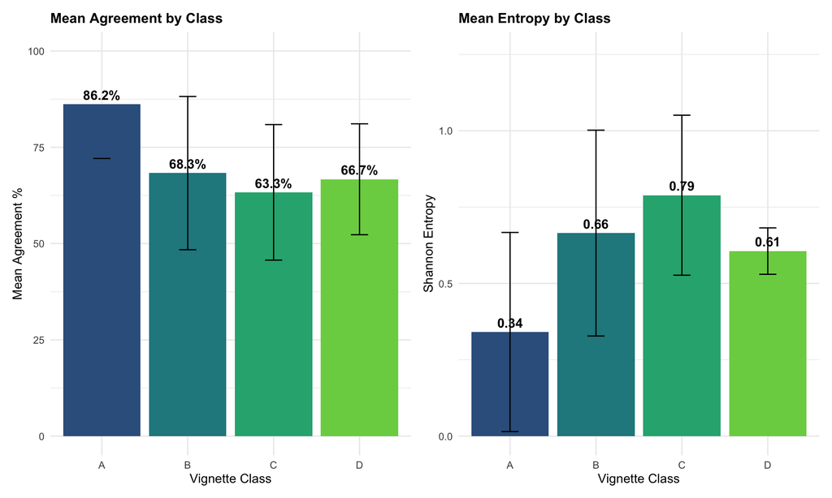

```r
# Agreement plot
p1 <- ggplot(class_summary, aes(x = vignette_class, y = mean_agreement_pct, fill = vignette_class)) +
  geom_col() +
  geom_errorbar(aes(ymin = mean_agreement_pct - sd_agreement_pct,
                    ymax = mean_agreement_pct + sd_agreement_pct),
                width = 0.2) +
  geom_text(aes(label = paste0(mean_agreement_pct, "%")), vjust = -0.5, size = 4, fontface = "bold") +
  scale_fill_viridis_d(option = "viridis", begin = 0.3, end = 0.8) +
  labs(title = "Mean Agreement by Class", x = "Vignette Class", y = "Mean Agreement %") +
  theme_minimal() +
  theme(plot.title = element_text(face = "bold", size = 12), legend.position = "none") +
  ylim(0, 100)

# Entropy plot
p2 <- ggplot(class_summary, aes(x = vignette_class, y = mean_entropy, fill = vignette_class)) +
  geom_col() +
  geom_errorbar(aes(ymin = mean_entropy - sd_entropy,
                    ymax = mean_entropy + sd_entropy),
                width = 0.2) +
  geom_text(aes(label = round(mean_entropy, 2)), vjust = -0.5, size = 4, fontface = "bold") +
  scale_fill_viridis_d(option = "viridis", begin = 0.3, end = 0.8) +
  labs(title = "Mean Entropy by Class", x = "Vignette Class", y = "Shannon Entropy") +
  theme_minimal() +
  theme(plot.title = element_text(face = "bold", size = 12), legend.position = "none") +
  ylim(0, max(class_summary$mean_entropy + class_summary$sd_entropy) * 1.2)

p1 + p2
```

# Table 2: Interrater Reliability Metrics (Gwet’s AC1)

## Replacement of Kappa with Gwet’s AC1

Because many vignettes were intentionally designed with one dominant “correct” response (e.g., clear medevac or clear remain), class prevalence is highly unbalanced. In such cases, Cohen’s κ and Fleiss’ κ produce spuriously low or even negative values despite high raw agreement—a phenomenon known as the kappa paradox.

To address this, interrater reliability was recalculated using **Gwet’s AC1**, which provides a more stable and interpretable measure under unbalanced category distributions. AC1 corrects the expected-by-chance term using an adjusted probability of agreement that is insensitive to marginal prevalence.

For this study: - **Class A (Right Answer)** and **Class B (Wrong Answer)** are analyzed using Gwet’s AC1 instead of κ - **Classes C and D** retain their descriptive and distributional analyses (entropy, binomial/χ² tests) since agreement per se is not the central construct

The resulting AC1 values better reflect true rater alignment with expert expectations and inter-clinician consistency.

Gwet’s AC1 measures agreement among multiple raters while accounting for chance agreement in unbalanced distributions.

**Interpretation:** - **< 0.20**: Slight agreement - **0.21-0.40**: Fair agreement - **0.41-0.60**: Moderate agreement - **0.61-0.80**: Substantial agreement - **0.81-1.00**: Almost perfect agreement

```r
# Calculate Gwet's AC1 for each vignette (Classes A and B only)
ac1_results <- data %>%
  filter(vignette_class %in% c("A", "B")) %>%  # Only apply to Classes A and B
  left_join(vignette_summary %>% select(question, subclass), by = "question") %>%
  group_by(question, vignette_label, vignette_class, question_type, subclass) %>%
  reframe({
    physicians <- unique(physician_id)
    decisions_vec <- character(length(physicians))

    for (i in seq_along(physicians)) {
      phys_decision <- decision[physician_id == physicians[i]]
      decisions_vec[i] <- ifelse(length(phys_decision) > 0, phys_decision[1], NA)
    }

    # Convert to numeric codes (1=Medevac, 2=Commercial, 3=Remain)
    decision_codes <- as.numeric(factor(decisions_vec, levels = c("Medevac", "Commercial", "Remain")))

    if (length(unique(na.omit(decision_codes))) > 1) {
      # Create ratings matrix for irrCAC (columns = raters, rows = items)
      ratings_matrix <- matrix(decision_codes, nrow = 1)

      ac1_result <- tryCatch({
        result <- gwet.ac1.raw(ratings_matrix)
        list(est = result$est$coeff.val, p.value = result$est$p.value)
      }, error = function(e) {
        list(est = NA, p.value = NA)
      })

      tibble(
        n_raters = length(na.omit(decision_codes)),
        gwet_ac1 = round(ac1_result$est, 3),
        p_value = ifelse(is.na(ac1_result$p.value), NA, round(ac1_result$p.value, 4)),
        interpretation = case_when(
          is.na(gwet_ac1) ~ "Cannot compute",
          gwet_ac1 < 0.20 ~ "Slight",
          gwet_ac1 < 0.41 ~ "Fair",
          gwet_ac1 < 0.61 ~ "Moderate",
          gwet_ac1 < 0.81 ~ "Substantial",
          TRUE ~ "Almost perfect"
        )
      )
    } else {
      tibble(
        n_raters = length(na.omit(decision_codes)),
        gwet_ac1 = NA,
        p_value = NA,
        interpretation = "Perfect agreement"
      )
    }
  }) %>%
  ungroup() %>%
  arrange(vignette_class, question)

# Join with agreement data
ac1_display <- ac1_results %>%
  left_join(
    vignette_summary %>% select(vignette_label, agreement_pct, entropy),
    by = "vignette_label"
  ) %>%
  select(
    Vignette = vignette_label,
    `Q#` = question,
    Subclass = subclass,
    `Agreement %` = agreement_pct,
    Entropy = entropy,
    `Gwet's AC1` = gwet_ac1,
    `p-value` = p_value,
    Interpretation = interpretation
  )

kable(ac1_display,
      caption = "Table 2: Interrater Reliability Metrics - Gwet's AC1 (Classes A and B Only)",
      align = c("c", "c", "c", "r", "r", "r", "r", "l"),
      digits = c(0, 0, 0, 1, 3, 3, 4, 0)) %>%
  kable_styling(
    bootstrap_options = c("striped", "hover", "condensed"),
    full_width = FALSE,
    position = "left"
  )
```

Table 2: Interrater Reliability Metrics - Gwet's AC1 (Classes A and B Only)

| Vignette | Q# | Subclass | Agreement % | Entropy | Gwet's AC1 | p-value | Interpretation |
| --- | --- | --- | --- | --- | --- | --- | --- |
| A1 | 1 | Medevac | 100 | 0.000 | NA | NA | Perfect agreement |
| A2 | 4 | Medevac | 95 | 0.199 | 0.889 | NA | Almost perfect |
| A3 | 8 | Remain | 80 | 0.613 | 0.576 | NA | Moderate |
| A4 | 9 | Commercial | 75 | 0.562 | 0.368 | NA | Fair |
| A5 | 11 | Remain | 75 | 0.562 | 0.368 | NA | Fair |
| A6 | 13 | Medevac | 100 | 0.000 | NA | NA | Perfect agreement |
| A7 | 15 | Commercial | 65 | 0.791 | 0.326 | NA | Fair |
| A8 | 19 | Medevac | 100 | 0.000 | NA | NA | Perfect agreement |
| B1 | 2 | No Medevac | 45 | 1.049 | 0.021 | NA | Slight |
| B2 | 5 | No Medevac | 75 | 0.562 | 0.368 | NA | Fair |
| B3 | 6 | No Medevac | 45 | 1.067 | -0.002 | NA | Slight |
| B4 | 7 | No Remain | 95 | 0.199 | 0.889 | NA | Almost perfect |
| B5 | 10 | No Remain | 70 | 0.611 | 0.238 | NA | Fair |
| B6 | 14 | No Medevac | 80 | 0.500 | 0.505 | NA | Moderate |

## AC1 Statistics by Class

```r
# AC1 statistics by class
ac1_class_summary <- ac1_results %>%
  group_by(vignette_class) %>%
  summarize(
    n_vignettes = n(),
    mean_ac1 = round(mean(gwet_ac1, na.rm = TRUE), 3),
    median_ac1 = round(median(gwet_ac1, na.rm = TRUE), 3),
    sd_ac1 = round(sd(gwet_ac1, na.rm = TRUE), 3),
    min_ac1 = round(min(gwet_ac1, na.rm = TRUE), 3),
    max_ac1 = round(max(gwet_ac1, na.rm = TRUE), 3),
    .groups = "drop"
  ) %>%
  arrange(vignette_class) %>%
  mutate(
    Group = vignette_class,
    Type = "Class"
  ) %>%
  select(
    Group,
    Type,
    `N Vignettes` = n_vignettes,
    `Mean AC1` = mean_ac1,
    `Median AC1` = median_ac1,
    `SD AC1` = sd_ac1,
    `Min AC1` = min_ac1,
    `Max AC1` = max_ac1
  )

# AC1 statistics by subclass
ac1_subclass_summary <- ac1_results %>%
  group_by(subclass) %>%
  summarize(
    n_vignettes = n(),
    mean_ac1 = round(mean(gwet_ac1, na.rm = TRUE), 3),
    median_ac1 = round(median(gwet_ac1, na.rm = TRUE), 3),
    sd_ac1 = round(sd(gwet_ac1, na.rm = TRUE), 3),
    min_ac1 = round(min(gwet_ac1, na.rm = TRUE), 3),
    max_ac1 = round(max(gwet_ac1, na.rm = TRUE), 3),
    .groups = "drop"
  ) %>%
  arrange(subclass) %>%
  mutate(Group = case_when(
    subclass %in% c("Medevac", "Commercial", "Remain") ~ "A",
    subclass %in% c("No Medevac", "No Remain") ~ "B",
    TRUE ~ "Other"
  )) %>%
  rename(
    Type = subclass,
    `N Vignettes` = n_vignettes,
    `Mean AC1` = mean_ac1,
    `Median AC1` = median_ac1,
    `SD AC1` = sd_ac1,
    `Min AC1` = min_ac1,
    `Max AC1` = max_ac1
  ) %>%
  select(Group, Type, everything())

# Combine class and subclass summaries
ac1_combined <- bind_rows(ac1_class_summary, ac1_subclass_summary)

kable(ac1_combined,
      caption = "Gwet's AC1 Statistics by Vignette Class and Subclass",
      align = c("c", "l", "c", "r", "r", "r", "r", "r")) %>%
  kable_styling(
    bootstrap_options = c("striped", "hover"),
    full_width = FALSE,
    position = "left"
  ) %>%
  pack_rows("Class A (Right Answer)", 1, 1) %>%
  pack_rows("A Subclasses", 2, 4) %>%
  pack_rows("Class B (Wrong Answer)", 5, 5) %>%
  pack_rows("B Subclasses", 6, 7)
```

Gwet's AC1 Statistics by Vignette Class and Subclass

[output not shown]

### Visualization: AC1 by Vignette

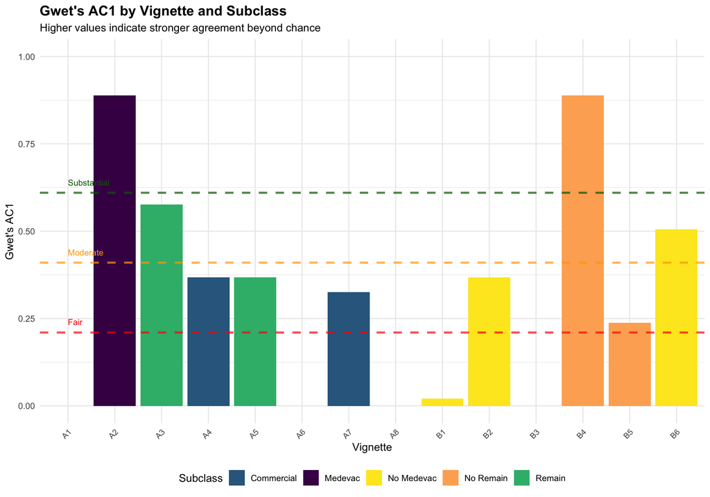

```r
# Plot AC1 values by subclass
ac1_results %>%
  mutate(vignette_label_factor = factor(vignette_label, levels = unique(vignette_label))) %>%
  ggplot(aes(x = vignette_label_factor, y = gwet_ac1, fill = subclass)) +
  geom_col() +
  geom_hline(yintercept = 0.61, linetype = "dashed", color = "darkgreen", linewidth = 1, alpha = 0.7) +
  geom_hline(yintercept = 0.41, linetype = "dashed", color = "orange", linewidth = 1, alpha = 0.7) +
  geom_hline(yintercept = 0.21, linetype = "dashed", color = "red", linewidth = 1, alpha = 0.7) +
  annotate("text", x = 1, y = 0.64, label = "Substantial", hjust = 0, size = 3, color = "darkgreen") +
  annotate("text", x = 1, y = 0.44, label = "Moderate", hjust = 0, size = 3, color = "orange") +
  annotate("text", x = 1, y = 0.24, label = "Fair", hjust = 0, size = 3, color = "red") +
  scale_fill_manual(values = c(
    "Medevac" = "#440154", "Commercial" = "#31688e", "Remain" = "#35b779",
    "No Medevac" = "#fde724", "No Remain" = "#fdae61"
  )) +
  labs(
    title = "Gwet's AC1 by Vignette and Subclass",
    subtitle = "Higher values indicate stronger agreement beyond chance",
    x = "Vignette",
    y = "Gwet's AC1",
    fill = "Subclass"
  ) +
  theme_minimal() +
  theme(
    plot.title = element_text(face = "bold", size = 14),
    axis.text.x = element_text(size = 8, angle = 45, hjust = 1),
    legend.position = "bottom"
  ) +
  ylim(0, 1)
```

### Statistical Comparison of Subclasses

```r
# Test for differences between subclasses within each class
ac1_subclass_stats <- ac1_results %>%
  group_by(subclass) %>%
  summarize(
    mean_ac1 = mean(gwet_ac1, na.rm = TRUE),
    sd_ac1 = sd(gwet_ac1, na.rm = TRUE),
    n = n(),
    se_ac1 = sd_ac1 / sqrt(n),
    ci_lower = mean_ac1 - 1.96 * se_ac1,
    ci_upper = mean_ac1 + 1.96 * se_ac1,
    .groups = "drop"
  )

# Pairwise comparisons for Class A subclasses
class_a_ac1 <- ac1_results %>% filter(vignette_class == "A") %>% pull(gwet_ac1)
a_medevac_ac1 <- ac1_results %>% filter(subclass == "A-Medevac") %>% pull(gwet_ac1)
a_commercial_ac1 <- ac1_results %>% filter(subclass == "A-Commercial") %>% pull(gwet_ac1)
a_remain_ac1 <- ac1_results %>% filter(subclass == "A-Remain") %>% pull(gwet_ac1)

# Effect sizes (Cohen's d) for Class A comparisons
d_medevac_commercial <- cohen.d(a_medevac_ac1, a_commercial_ac1)$estimate
d_medevac_remain <- cohen.d(a_medevac_ac1, a_remain_ac1)$estimate
d_commercial_remain <- cohen.d(a_commercial_ac1, a_remain_ac1)$estimate

# Display subclass comparison results
subclass_comparison <- data.frame(
  Comparison = c("A-Medevac vs A-Commercial", "A-Medevac vs A-Remain", "A-Commercial vs A-Remain"),
  Cohen_d = c(round(d_medevac_commercial, 2), round(d_medevac_remain, 2), round(d_commercial_remain, 2)),
  Interpretation = c(
    ifelse(abs(d_medevac_commercial) < 0.2, "Negligible",
    ifelse(abs(d_medevac_commercial) < 0.5, "Small",
    ifelse(abs(d_medevac_commercial) < 0.8, "Medium", "Large"))),
    ifelse(abs(d_medevac_remain) < 0.2, "Negligible",
    ifelse(abs(d_medevac_remain) < 0.5, "Small",
    ifelse(abs(d_medevac_remain) < 0.8, "Medium", "Large"))),
    ifelse(abs(d_commercial_remain) < 0.2, "Negligible",
    ifelse(abs(d_commercial_remain) < 0.5, "Small",
    ifelse(abs(d_commercial_remain) < 0.8, "Medium", "Large")))
  )
)

kable(subclass_comparison,
      caption = "Effect Size Comparisons Between A Subclasses",
      col.names = c("Comparison", "Cohen's d", "Effect Size")) %>%
  kable_styling(
    bootstrap_options = c("striped", "hover"),
    full_width = FALSE
  )
```

Effect Size Comparisons Between A Subclasses

| Comparison | Cohen's d | Effect Size |
| --- | --- | --- |
| A-Medevac vs A-Commercial | NaN | NA |
| A-Medevac vs A-Remain | NaN | NA |
| A-Commercial vs A-Remain | NaN | NA |

# Vignette Class Analyses

The following sections analyze each vignette class according to its unique conceptual framework and statistical approach as outlined in the analysis plan.

# Class A: Right Answer (Clear Correct Choice)

**Definition:** Vignettes where expert consensus suggests one preferred management option, but reasonable alternatives exist.

**Objective:** Measure alignment with expert guidance and degree of agreement among physicians.

**Note:** This analysis requires expert reference answers for each Class A vignette to be added to the dataset.

```r
# Filter Class A data
class_a_data <- data %>% filter(vignette_class == "A")
class_a_vignettes <- vignette_summary %>% filter(vignette_class == "A")

cat("**Class A Summary**\n\n")
```

```
**Class A Summary**
```

```r
cat(sprintf("- Number of vignettes: %d\n", nrow(class_a_vignettes)))
```

```
- Number of vignettes: 8
```

```r
cat(sprintf("- Total responses: %d\n", nrow(class_a_data)))
```

```
- Total responses: 160
```

```r
cat(sprintf("- Mean agreement: %.1f%% (SD = %.1f)\n",
            mean(class_a_vignettes$agreement_pct),
            sd(class_a_vignettes$agreement_pct)))
```

```
- Mean agreement: 86.2% (SD = 14.1)
```

```r
cat(sprintf("- Mean entropy: %.3f (SD = %.3f)\n",
            mean(class_a_vignettes$entropy),
            sd(class_a_vignettes$entropy)))
```

```
- Mean entropy: 0.341 (SD = 0.326)
```

```r
cat(sprintf("- Mean Gwet's AC1: %.3f\n",
            mean(ac1_results$gwet_ac1[ac1_results$vignette_class == "A"], na.rm = TRUE)))
```

```
- Mean Gwet's AC1: 0.505
```

## Descriptive Statistics

```r
class_a_summary <- class_a_vignettes %>%
  select(
    Vignette = vignette_label,
    `Q#` = question,
    `Question Type` = question_type,
    `Modal Decision` = modal_decision,
    `Agreement %` = agreement_pct,
    Entropy = entropy,
    `Mean Conf.` = mean_confidence
  )

kable(class_a_summary,
      caption = "Class A: Descriptive Statistics",
      align = c("c", "c", "l", "l", "r", "r", "r"),
      digits = c(0, 0, 0, 0, 1, 3, 1)) %>%
  kable_styling(
    bootstrap_options = c("striped", "hover"),
    full_width = FALSE
  ) %>%
  column_spec(1, bold = TRUE)
```

Class A: Descriptive Statistics

| Vignette | Q# | Question Type | Modal Decision | Agreement % | Entropy | Mean Conf. |
| --- | --- | --- | --- | --- | --- | --- |
| A1 | 1 | Clear Medevac | Medevac | 100 | 0.000 | 9.3 |
| A2 | 4 | Clear Medevac | Medevac | 95 | 0.199 | 8.8 |
| A3 | 8 | Clear Remain | Remain | 80 | 0.613 | 7.3 |
| A4 | 9 | Clear Commercial | Commercial | 75 | 0.562 | 7.3 |
| A5 | 11 | Clear Remain | Remain | 75 | 0.562 | 7.2 |
| A6 | 13 | Clear Medevac | Medevac | 100 | 0.000 | 9.3 |
| A7 | 15 | Clear Commercial | Medevac | 65 | 0.791 | 7.7 |
| A8 | 19 | Clear Medevac | Medevac | 100 | 0.000 | 9.0 |

## Visualization: Decision Heatmap

```r
# Create heatmap of decisions (physicians x vignettes)
class_a_matrix <- class_a_data %>%
  select(physician_id, vignette_label, decision) %>%
  mutate(
    decision_code = case_when(
      decision == "Medevac" ~ 1,
      decision == "Commercial" ~ 2,
      decision == "Remain" ~ 3,
      TRUE ~ NA_real_
    )
  ) %>%
  pivot_wider(
    names_from = vignette_label,
    values_from = decision_code
  )

# Convert to matrix with physician IDs as row names
class_a_phys_ids <- as.character(class_a_matrix$physician_id)
class_a_matrix_data <- class_a_matrix[, -1]

# Convert all columns to numeric
class_a_matrix_data <- lapply(class_a_matrix_data, as.numeric)
class_a_matrix <- do.call(cbind, class_a_matrix_data)
rownames(class_a_matrix) <- class_a_phys_ids

# Check if there are any NA values and handle them
if (any(is.na(class_a_matrix))) {
  # If NAs present, don't cluster or fill NAs
  cat("Note: Some missing values in data, clustering disabled.\n")
  cluster_rows_setting <- FALSE
} else {
  cluster_rows_setting <- TRUE
}
```

```
Note: Some missing values in data, clustering disabled.
```

[figure not shown]

```r
# Plot heatmap
if (knitr::is_html_output()) {
  pheatmap(
    class_a_matrix,
    color = c("#e74c3c", "#3498db", "#2ecc71"),
    breaks = c(0.5, 1.5, 2.5, 3.5),
    legend_breaks = c(1, 2, 3),
    legend_labels = c("Medevac", "Commercial", "Remain"),
    main = "Class A: Physician Decisions Across Vignettes",
    cluster_rows = cluster_rows_setting,
    cluster_cols = FALSE,
    show_rownames = TRUE,
    show_colnames = TRUE,
    fontsize = 10,
    na_col = "gray80"
  )
} else {
  # For PDF/DOCX, create a simple static plot
  heatmap_matrix <- class_a_matrix
  image(1:ncol(heatmap_matrix), 1:nrow(heatmap_matrix), t(heatmap_matrix),
        col = c("#e74c3c", "#3498db", "#2ecc71"),
        breaks = c(0.5, 1.5, 2.5, 3.5),
        axes = FALSE, xlab = "", ylab = "")
  axis(1, at = 1:ncol(heatmap_matrix), labels = colnames(heatmap_matrix), las = 2)
  axis(2, at = 1:nrow(heatmap_matrix), labels = rownames(heatmap_matrix), las = 2)
  title("Class A: Physician Decisions Across Vignettes")
  legend("topright", legend = c("Medevac", "Commercial", "Remain"),
         fill = c("#e74c3c", "#3498db", "#2ecc71"))
}
```

## Mixed-Effects Logistic Regression (GLMM)

```r
# Placeholder for GLMM when expert consensus data is available
# This code will run once 'expert_decision' column is added

# class_a_data_glmm <- class_a_data %>%
#   mutate(matches_expert = ifelse(decision == expert_decision, 1, 0))
#
# model_a <- glmer(
#   matches_expert ~ 1 + (1|physician_id) + (1|vignette_label),
#   data = class_a_data_glmm,
#   family = binomial
# )
#
# summary(model_a)
```

# Class B: Wrong Answer (Clear Incorrect Choice)

**Definition:** Vignettes with one clearly discouraged or clinically inappropriate option; two responses considered acceptable.

**Objective:** Identify how consistently clinicians avoid the discouraged response.

**Note:** Requires expert classification of which option is “discouraged” for each Class B vignette.

```r
class_b_data <- data %>% filter(vignette_class == "B")
class_b_vignettes <- vignette_summary %>% filter(vignette_class == "B")

cat("**Class B Summary**\n\n")
```

```
**Class B Summary**
```

```r
cat(sprintf("- Number of vignettes: %d\n", nrow(class_b_vignettes)))
```

```
- Number of vignettes: 6
```

```r
cat(sprintf("- Total responses: %d\n", nrow(class_b_data)))
```

```
- Total responses: 120
```

```r
cat(sprintf("- Mean agreement: %.1f%% (SD = %.1f)\n",
            mean(class_b_vignettes$agreement_pct),
            sd(class_b_vignettes$agreement_pct)))
```

```
- Mean agreement: 68.3% (SD = 19.9)
```

```r
cat(sprintf("- Mean entropy: %.3f (SD = %.3f)\n",
            mean(class_b_vignettes$entropy),
            sd(class_b_vignettes$entropy)))
```

```
- Mean entropy: 0.665 (SD = 0.337)
```

```r
cat(sprintf("- Mean Gwet's AC1: %.3f\n",
            mean(ac1_results$gwet_ac1[ac1_results$vignette_class == "B"], na.rm = TRUE)))
```

```
- Mean Gwet's AC1: 0.337
```

## Descriptive Statistics

```r
class_b_summary <- class_b_vignettes %>%
  select(
    Vignette = vignette_label,
    `Q#` = question,
    `Question Type` = question_type,
    `Medevac %` = pct_medevac,
    `Commercial %` = pct_commercial,
    `Remain %` = pct_remain,
    Entropy = entropy,
    `Mean Conf.` = mean_confidence
  )

kable(class_b_summary,
      caption = "Class B: Descriptive Statistics",
      align = c("c", "c", "l", "r", "r", "r", "r", "r"),
      digits = c(0, 0, 0, 1, 1, 1, 3, 1)) %>%
  kable_styling(
    bootstrap_options = c("striped", "hover"),
    full_width = FALSE
  ) %>%
  column_spec(1, bold = TRUE)
```

Class B: Descriptive Statistics

| Vignette | Q# | Question Type | Medevac % | Commercial % | Remain % | Entropy | Mean Conf. |
| --- | --- | --- | --- | --- | --- | --- | --- |
| B1 | 2 | Clear Not Medevac | 20 | 45 | 35 | 1.049 | 7.2 |
| B2 | 5 | Clear Not Medevac | 0 | 75 | 25 | 0.562 | 7.7 |
| B3 | 6 | Clear Not Medevac | 25 | 45 | 30 | 1.067 | 7.0 |
| B4 | 7 | Clear Not Remain | 95 | 5 | 0 | 0.199 | 9.4 |
| B5 | 10 | Clear Not Remain | 70 | 30 | 0 | 0.611 | 8.0 |
| B6 | 14 | Clear Not Medevac | 0 | 20 | 80 | 0.500 | 7.4 |

## Visualization: Stacked Bar Chart

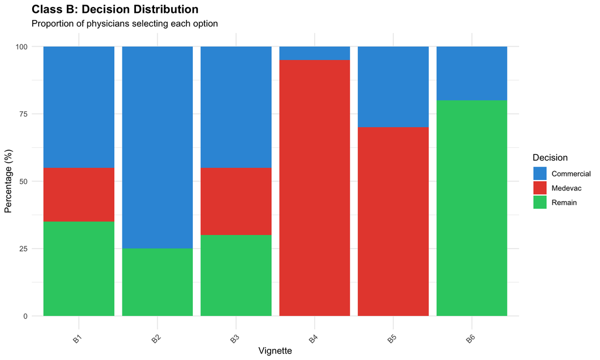

```r
class_b_long <- class_b_vignettes %>%
  select(vignette_label, pct_medevac, pct_commercial, pct_remain) %>%
  pivot_longer(
    cols = c(pct_medevac, pct_commercial, pct_remain),
    names_to = "decision",
    values_to = "percentage"
  ) %>%
  mutate(
    decision = case_when(
      decision == "pct_medevac" ~ "Medevac",
      decision == "pct_commercial" ~ "Commercial",
      decision == "pct_remain" ~ "Remain"
    )
  )

ggplot(class_b_long, aes(x = vignette_label, y = percentage, fill = decision)) +
  geom_col(position = "stack") +
  scale_fill_manual(values = c("Medevac" = "#e74c3c", "Commercial" = "#3498db", "Remain" = "#2ecc71")) +
  labs(
    title = "Class B: Decision Distribution",
    subtitle = "Proportion of physicians selecting each option",
    x = "Vignette",
    y = "Percentage (%)",
    fill = "Decision"
  ) +
  theme_minimal() +
  theme(
    plot.title = element_text(face = "bold", size = 14),
    axis.text.x = element_text(angle = 45, hjust = 1)
  )
```

## Binomial Test

Testing whether the frequency of each decision differs from chance (33.3%).

```r
# Test for each decision type - using rowwise for binomial test
binomial_results <- class_b_data %>%
  group_by(vignette_label, decision) %>%
  summarize(count = n(), .groups = "drop") %>%
  group_by(vignette_label) %>%
  mutate(
    total = sum(count),
    observed_prop = count / total,
    expected_prop = 1/3
  ) %>%
  ungroup() %>%
  rowwise() %>%
  mutate(
    binom_p = binom.test(count, total, p = 1/3)$p.value
  ) %>%
  ungroup()

# Summary by decision type across all Class B vignettes
binomial_summary <- class_b_data %>%
  group_by(decision) %>%
  summarize(
    n_responses = n(),
    .groups = "drop"
  ) %>%
  mutate(
    total_possible = nrow(class_b_data),
    observed_pct = round(100 * n_responses / total_possible, 1),
    expected_pct = 33.3
  ) %>%
  rowwise() %>%
  mutate(
    binom_test_p = binom.test(n_responses, total_possible, p = 1/3)$p.value
  ) %>%
  ungroup()

kable(binomial_summary,
      caption = "Class B: Binomial Test Results (Overall)",
      digits = c(0, 0, 0, 1, 1, 4),
      col.names = c("Decision", "N Responses", "Total Possible", "Observed %", "Expected %", "p-value")) %>%
  kable_styling(
    bootstrap_options = c("striped", "hover"),
    full_width = FALSE
  ) %>%
  column_spec(6, bold = TRUE, color = ifelse(binomial_summary$binom_test_p < 0.05, "darkgreen", "black"))
```

Class B: Binomial Test Results (Overall)

| Decision | N Responses | Total Possible | Observed % | Expected % | p-value |
| --- | --- | --- | --- | --- | --- |
| Commercial | 44 | 120 | 36.7 | 33.3 | 0.4397 |
| Medevac | 42 | 120 | 35.0 | 33.3 | 0.6992 |
| Remain | 34 | 120 | 28.3 | 33.3 | 0.2867 |

# Class C: Ambiguous (All Plausible Options)

**Definition:** Vignettes intentionally designed with high uncertainty where all three options are clinically reasonable.

**Objective:** Characterize decision diversity and patterns under ambiguity.

```r
class_c_data <- data %>% filter(vignette_class == "C")
class_c_vignettes <- vignette_summary %>% filter(vignette_class == "C")

cat("**Class C Summary**\n\n")
```

```
**Class C Summary**
```

```r
cat(sprintf("- Number of vignettes: %d\n", nrow(class_c_vignettes)))
```

```
- Number of vignettes: 3
```

```r
cat(sprintf("- Total responses: %d\n", nrow(class_c_data)))
```

```
- Total responses: 60
```

```r
cat(sprintf("- Mean agreement: %.1f%% (SD = %.1f)\n",
            mean(class_c_vignettes$agreement_pct),
            sd(class_c_vignettes$agreement_pct)))
```

```
- Mean agreement: 63.3% (SD = 17.6)
```

```r
cat(sprintf("- Mean entropy: %.3f (SD = %.3f) - **Higher = Greater Diversity**\n",
            mean(class_c_vignettes$entropy),
            sd(class_c_vignettes$entropy)))
```

```
- Mean entropy: 0.789 (SD = 0.262) - **Higher = Greater Diversity**
```

```r
cat(sprintf("- AC1 not computed (ambiguous cases - agreement not central construct)\n"))
```

```
- AC1 not computed (ambiguous cases - agreement not central construct)
```

## Descriptive Statistics

```r
class_c_summary <- class_c_vignettes %>%
  select(
    Vignette = vignette_label,
    `Q#` = question,
    `Medevac %` = pct_medevac,
    `Commercial %` = pct_commercial,
    `Remain %` = pct_remain,
    Entropy = entropy,
    `Agreement %` = agreement_pct,
    `Mean Conf.` = mean_confidence
  )

kable(class_c_summary,
      caption = "Class C: Descriptive Statistics",
      align = c("c", "c", "r", "r", "r", "r", "r", "r"),
      digits = c(0, 0, 1, 1, 1, 3, 1, 1)) %>%
  kable_styling(
    bootstrap_options = c("striped", "hover"),
    full_width = FALSE
  ) %>%
  column_spec(1, bold = TRUE) %>%
  column_spec(6, bold = TRUE)
```

Class C: Descriptive Statistics

| Vignette | Q# | Medevac % | Commercial % | Remain % | Entropy | Agreement % | Mean Conf. |
| --- | --- | --- | --- | --- | --- | --- | --- |
| C1 | 3 | 20 | 0 | 80 | 0.500 | 80 | 6.9 |
| C2 | 12 | 45 | 40 | 15 | 1.010 | 45 | 6.2 |
| C3 | 20 | 65 | 25 | 10 | 0.857 | 65 | 7.1 |

## Chi-Square Goodness-of-Fit Test

Testing for deviation from equal distribution (33.3% each option).

```r
chisq_results <- class_c_data %>%
  group_by(vignette_label) %>%
  summarize(
    n_medevac = sum(decision == "Medevac"),
    n_commercial = sum(decision == "Commercial"),
    n_remain = sum(decision == "Remain"),
    total = n(),
    .groups = "drop"
  ) %>%
  rowwise() %>%
  mutate(
    chisq_stat = {
      observed <- c(n_medevac, n_commercial, n_remain)
      expected <- rep(total/3, 3)
      sum((observed - expected)^2 / expected)
    },
    chisq_p = pchisq(chisq_stat, df = 2, lower.tail = FALSE)
  ) %>%
  select(Vignette = vignette_label, `χ² Statistic` = chisq_stat, `p-value` = chisq_p)

kable(chisq_results,
      caption = "Class C: Chi-Square Goodness-of-Fit Tests",
      digits = c(0, 2, 4)) %>%
  kable_styling(
    bootstrap_options = c("striped", "hover"),
    full_width = FALSE
  ) %>%
  column_spec(3, bold = TRUE, color = ifelse(chisq_results$`p-value` < 0.05, "darkgreen", "black"))
```

Class C: Chi-Square Goodness-of-Fit Tests

| Vignette | χ² Statistic | p-value |
| --- | --- | --- |
| C1 | 20.8 | 0.0000 |
| C2 | 3.1 | 0.2122 |
| C3 | 9.7 | 0.0078 |

## Visualization: Decision Balance

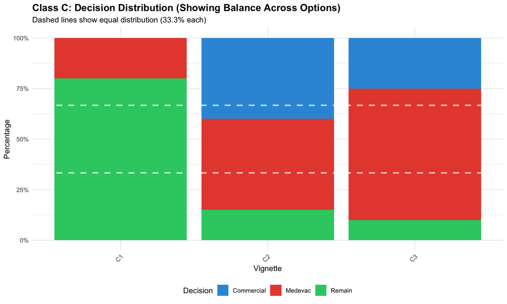

```r
# Alternative visualization: stacked bars showing proportions
class_c_long <- class_c_vignettes %>%
  select(vignette_label, pct_medevac, pct_commercial, pct_remain) %>%
  pivot_longer(
    cols = c(pct_medevac, pct_commercial, pct_remain),
    names_to = "decision",
    values_to = "percentage"
  ) %>%
  mutate(
    decision = case_when(
      decision == "pct_medevac" ~ "Medevac",
      decision == "pct_commercial" ~ "Commercial",
      decision == "pct_remain" ~ "Remain"
    )
  )

ggplot(class_c_long, aes(x = vignette_label, y = percentage, fill = decision)) +
  geom_col(position = "fill") +
  geom_hline(yintercept = 0.333, linetype = "dashed", color = "white", linewidth = 1, alpha = 0.7) +
  geom_hline(yintercept = 0.667, linetype = "dashed", color = "white", linewidth = 1, alpha = 0.7) +
  scale_fill_manual(values = c("Medevac" = "#e74c3c", "Commercial" = "#3498db", "Remain" = "#2ecc71")) +
  scale_y_continuous(labels = scales::percent) +
  labs(
    title = "Class C: Decision Distribution (Showing Balance Across Options)",
    subtitle = "Dashed lines show equal distribution (33.3% each)",
    x = "Vignette",
    y = "Percentage",
    fill = "Decision"
  ) +
  theme_minimal() +
  theme(
    plot.title = element_text(face = "bold", size = 14),
    axis.text.x = element_text(angle = 45, hjust = 1),
    legend.position = "bottom"
  )
```

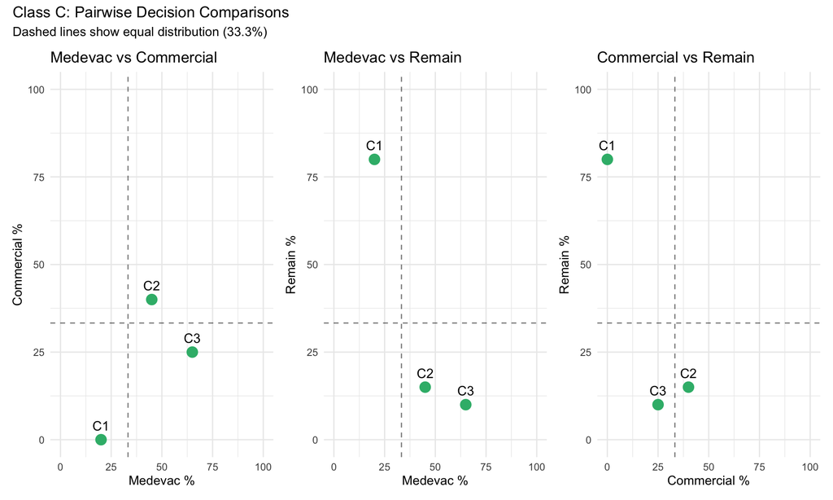

```r
# Also show a scatter plot matrix
p1 <- ggplot(class_c_vignettes, aes(x = pct_medevac, y = pct_commercial)) +
  geom_point(size = 4, color = "#35b779") +
  geom_text(aes(label = vignette_label), vjust = -1, size = 4) +
  geom_vline(xintercept = 33.3, linetype = "dashed", alpha = 0.5) +
  geom_hline(yintercept = 33.3, linetype = "dashed", alpha = 0.5) +
  labs(x = "Medevac %", y = "Commercial %", title = "Medevac vs Commercial") +
  theme_minimal() +
  xlim(0, 100) + ylim(0, 100)

p2 <- ggplot(class_c_vignettes, aes(x = pct_medevac, y = pct_remain)) +
  geom_point(size = 4, color = "#35b779") +
  geom_text(aes(label = vignette_label), vjust = -1, size = 4) +
  geom_vline(xintercept = 33.3, linetype = "dashed", alpha = 0.5) +
  geom_hline(yintercept = 33.3, linetype = "dashed", alpha = 0.5) +
  labs(x = "Medevac %", y = "Remain %", title = "Medevac vs Remain") +
  theme_minimal() +
  xlim(0, 100) + ylim(0, 100)

p3 <- ggplot(class_c_vignettes, aes(x = pct_commercial, y = pct_remain)) +
  geom_point(size = 4, color = "#35b779") +
  geom_text(aes(label = vignette_label), vjust = -1, size = 4) +
  geom_vline(xintercept = 33.3, linetype = "dashed", alpha = 0.5) +
  geom_hline(yintercept = 33.3, linetype = "dashed", alpha = 0.5) +
  labs(x = "Commercial %", y = "Remain %", title = "Commercial vs Remain") +
  theme_minimal() +
  xlim(0, 100) + ylim(0, 100)

# Combine plots
(p1 + p2 + p3) +
  plot_annotation(
    title = "Class C: Pairwise Decision Comparisons",
    subtitle = "Dashed lines show equal distribution (33.3%)"
  )
```

# Class D: Situational (Operationally Constrained Emergencies)

**Definition:** True emergencies where decisions are shaped by logistical constraints. Typically shows bimodal split (Medevac vs Remain).

**Objective:** Characterize variability under operational constraints - variation itself is meaningful.

```r
class_d_data <- data %>% filter(vignette_class == "D")
class_d_vignettes <- vignette_summary %>% filter(vignette_class == "D")

cat("**Class D Summary**\n\n")
```

```
**Class D Summary**
```

```r
cat(sprintf("- Number of vignettes: %d\n", nrow(class_d_vignettes)))
```

```
- Number of vignettes: 3
```

```r
cat(sprintf("- Total responses: %d\n", nrow(class_d_data)))
```

```
- Total responses: 60
```

```r
cat(sprintf("- Mean agreement: %.1f%% (SD = %.1f)\n",
            mean(class_d_vignettes$agreement_pct),
            sd(class_d_vignettes$agreement_pct)))
```

```
- Mean agreement: 66.7% (SD = 14.4)
```

```r
cat(sprintf("- Mean entropy: %.3f (SD = %.3f)\n",
            mean(class_d_vignettes$entropy),
            sd(class_d_vignettes$entropy)))
```

```
- Mean entropy: 0.606 (SD = 0.076)
```

```r
cat(sprintf("- Mean %% Medevac: %.1f%%\n",
            mean(class_d_vignettes$pct_medevac)))
```

```
- Mean % Medevac: 50.0%
```

```r
cat(sprintf("- Mean %% Remain: %.1f%%\n",
            mean(class_d_vignettes$pct_remain)))
```

```
- Mean % Remain: 50.0%
```

```r
cat(sprintf("- Mean %% Commercial: %.1f%% (typically low)\n",
            mean(class_d_vignettes$pct_commercial)))
```

```
- Mean % Commercial: 0.0% (typically low)
```

## Descriptive Statistics

```r
class_d_summary <- class_d_vignettes %>%
  select(
    Vignette = vignette_label,
    `Q#` = question,
    `Medevac %` = pct_medevac,
    `Commercial %` = pct_commercial,
    `Remain %` = pct_remain,
    Entropy = entropy,
    `Mean Conf.` = mean_confidence
  )

kable(class_d_summary,
      caption = "Class D: Descriptive Statistics",
      align = c("c", "c", "r", "r", "r", "r", "r"),
      digits = c(0, 0, 1, 1, 1, 3, 1)) %>%
  kable_styling(
    bootstrap_options = c("striped", "hover"),
    full_width = FALSE
  ) %>%
  column_spec(1, bold = TRUE)
```

Class D: Descriptive Statistics

| Vignette | Q# | Medevac % | Commercial % | Remain % | Entropy | Mean Conf. |
| --- | --- | --- | --- | --- | --- | --- |
| D1 | 16 | 75 | 0 | 25 | 0.562 | 7.2 |
| D2 | 17 | 50 | 0 | 50 | 0.693 | 7.0 |
| D3 | 18 | 25 | 0 | 75 | 0.562 | 8.3 |

## Binomial Test: Medevac vs Remain

Testing whether the Medevac/Remain split differs from 50/50.

```r
# Test for bimodal split (excluding commercial for this test)
binomial_d_results <- class_d_data %>%
  filter(decision %in% c("Medevac", "Remain")) %>%
  group_by(vignette_label) %>%
  summarize(
    n_medevac = sum(decision == "Medevac"),
    n_total = n(),
    pct_medevac = round(100 * n_medevac / n_total, 1),
    .groups = "drop"
  ) %>%
  rowwise() %>%
  mutate(
    binom_p = binom.test(n_medevac, n_total, p = 0.5)$p.value
  ) %>%
  ungroup() %>%
  rename(
    Vignette = vignette_label,
    `N Medevac` = n_medevac,
    `N Total` = n_total,
    `% Medevac` = pct_medevac,
    `p-value` = binom_p
  )

kable(binomial_d_results,
      caption = "Class D: Binomial Test Results (Medevac vs Remain)",
      digits = c(0, 0, 0, 1, 4)) %>%
  kable_styling(
    bootstrap_options = c("striped", "hover"),
    full_width = FALSE
  ) %>%
  column_spec(5, bold = TRUE, color = ifelse(binomial_d_results$`p-value` < 0.05, "darkgreen", "black"))
```

Class D: Binomial Test Results (Medevac vs Remain)

| Vignette | N Medevac | N Total | % Medevac | p-value |
| --- | --- | --- | --- | --- |
| D1 | 15 | 20 | 75 | 0.0414 |
| D2 | 10 | 20 | 50 | 1.0000 |
| D3 | 5 | 20 | 25 | 0.0414 |

## Visualization: Diverging Bar Plot

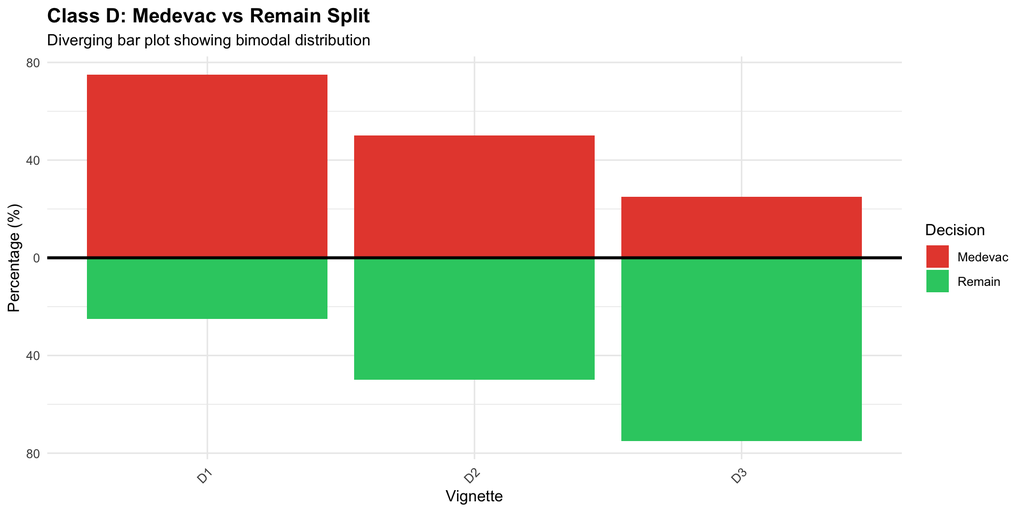

```r
# Create diverging bar plot
class_d_diverging <- class_d_vignettes %>%
  mutate(
    medevac_pct = pct_medevac,
    remain_pct = -pct_remain  # Negative for diverging effect
  ) %>%
  select(vignette_label, medevac_pct, remain_pct) %>%
  pivot_longer(
    cols = c(medevac_pct, remain_pct),
    names_to = "decision",
    values_to = "percentage"
  ) %>%
  mutate(
    decision = ifelse(decision == "medevac_pct", "Medevac", "Remain")
  )

ggplot(class_d_diverging, aes(x = vignette_label, y = percentage, fill = decision)) +
  geom_col() +
  scale_fill_manual(values = c("Medevac" = "#e74c3c", "Remain" = "#2ecc71")) +
  geom_hline(yintercept = 0, color = "black", linewidth = 1) +
  labs(
    title = "Class D: Medevac vs Remain Split",
    subtitle = "Diverging bar plot showing bimodal distribution",
    x = "Vignette",
    y = "Percentage (%)",
    fill = "Decision"
  ) +
  theme_minimal() +
  theme(
    plot.title = element_text(face = "bold", size = 14),
    axis.text.x = element_text(angle = 45, hjust = 1)
  ) +
  scale_y_continuous(labels = abs)
```

## Visualization: Decision Heatmap

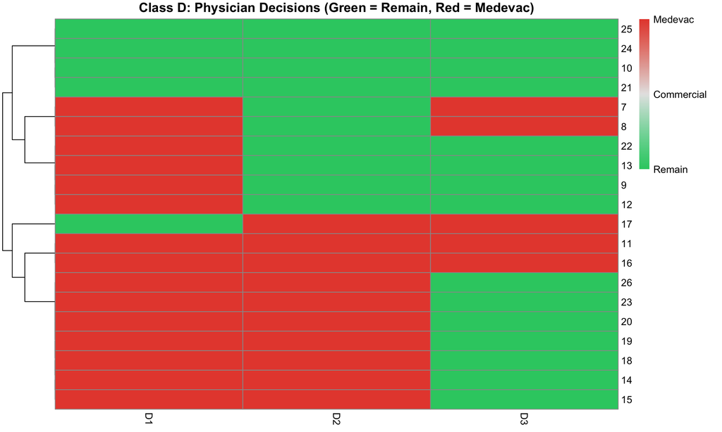

```r
# Create heatmap (focus on Medevac vs Remain)
class_d_matrix <- class_d_data %>%
  mutate(
    decision_binary = case_when(
      decision == "Medevac" ~ 1,
      decision == "Remain" ~ 0,
      decision == "Commercial" ~ 0.5,
      TRUE ~ NA_real_
    )
  ) %>%
  select(physician_id, vignette_label, decision_binary) %>%
  pivot_wider(
    names_from = vignette_label,
    values_from = decision_binary
  )

# Convert to matrix with physician IDs as row names
class_d_phys_ids <- as.character(class_d_matrix$physician_id)
class_d_matrix_data <- class_d_matrix[, -1]

# Convert all columns to numeric
class_d_matrix_data <- lapply(class_d_matrix_data, as.numeric)
class_d_matrix <- do.call(cbind, class_d_matrix_data)
rownames(class_d_matrix) <- class_d_phys_ids

# Check if there are any NA values and handle them
if (any(is.na(class_d_matrix))) {
  cat("Note: Some missing values in data, clustering disabled.\n")
  cluster_rows_d <- FALSE
} else {
  cluster_rows_d <- TRUE
}

if (knitr::is_html_output()) {
  pheatmap(
    class_d_matrix,
    color = colorRampPalette(c("#2ecc71", "gray90", "#e74c3c"))(100),
    breaks = seq(0, 1, length.out = 101),
    main = "Class D: Physician Decisions (Green = Remain, Red = Medevac)",
    cluster_rows = cluster_rows_d,
    cluster_cols = FALSE,
    show_rownames = TRUE,
    show_colnames = TRUE,
    fontsize = 10,
    legend_breaks = c(0, 0.5, 1),
    legend_labels = c("Remain", "Commercial", "Medevac"),
    na_col = "gray80"
  )
} else {
  # For PDF/DOCX, create a simple static plot
  image(1:ncol(class_d_matrix), 1:nrow(class_d_matrix), t(class_d_matrix),
        col = colorRampPalette(c("#2ecc71", "gray90", "#e74c3c"))(100),
        breaks = seq(0, 1, length.out = 101),
        axes = FALSE, xlab = "", ylab = "")
  axis(1, at = 1:ncol(class_d_matrix), labels = colnames(class_d_matrix), las = 2)
  axis(2, at = 1:nrow(class_d_matrix), labels = rownames(class_d_matrix), las = 2)
  title("Class D: Physician Decisions (Green = Remain, Red = Medevac)")
}
```

# Summary and Conclusions

## Key Findings

1. **Overall Agreement**: Mean agreement across all vignettes was 74.5%
2. **Gwet’s AC1**: Mean AC1 = 0.413 (Classes A & B only)
3. **Entropy**: Mean entropy = 0.545 (higher = more diversity)

## By Class

```r
final_summary <- class_summary %>%
  left_join(
    ac1_class_summary %>% select(Group, `Mean AC1`),
    by = c("vignette_class" = "Group")
  ) %>%
  select(
    Class = vignette_class,
    `N` = n_vignettes,
    `Mean Agreement %` = mean_agreement_pct,
    `Mean Entropy` = mean_entropy,
    `Mean AC1` = `Mean AC1`,
    `Mean Confidence` = mean_confidence
  )

kable(final_summary,
      caption = "Summary Statistics by Class",
      digits = c(0, 0, 1, 3, 3, 1)) %>%
  kable_styling(
    bootstrap_options = c("striped", "hover"),
    full_width = FALSE
  ) %>%
  column_spec(1, bold = TRUE, color = "white", background = c("#440154", "#31688e", "#35b779", "#fde724"))
```

Summary Statistics by Class

| Class | N | Mean Agreement % | Mean Entropy | Mean AC1 | Mean Confidence |
| --- | --- | --- | --- | --- | --- |
| A | 8 | 86.2 | 0.341 | 0.505 | 8.2 |
| B | 6 | 68.3 | 0.665 | 0.336 | 7.8 |
| C | 3 | 63.3 | 0.789 | NA | 6.7 |
| D | 3 | 66.7 | 0.606 | NA | 7.5 |

## Next Steps

1. **Add expert reference answers** for Classes A and B to enable:
   - Expert consensus alignment analysis (Class A)
   - Discouraged option avoidance analysis (Class B)
   - Cohen’s κ comparisons
2. **Implement full GLMM analyses** with random intercepts for physician and vignette to account for repeated measures structure
3. **Additional visualizations** as needed for publication

**Report Generated:** 2025-11-10